# Lab-8 Template

Change title and notebook name to reflect your work.

Answer questions in the designated cells

Resources:

- https://github.com/slundberg/shap
- H2O Explainability best practices: https://github.com/h2oai/h2o-tutorials/blob/master/best-practices/model-interpretability/interpreting_models.ipynb

## Preparation

Use dataset provided in the eLearning

```python
#Extend cell width
from IPython.core.display import display, HTML
display(HTML("<style>.container { width:80% !important; }</style>"))

import warnings
warnings.filterwarnings('ignore')

import pandas as pd

#Install shap package as needed:
#!pip uninstall numpy
#!pip uninstall numba
!pip install shap==0.40.0

import shap

import h2o
from h2o.estimators import H2OTargetEncoderEstimator

try:
    h2o.cluster().shutdown()
except:
    pass
```

```python
#Limit to 3 threads and 8GB memory - modify as needed
h2o.init(nthreads=3, max_mem_size=8)
```

```
Checking whether there is an H2O instance running at http://localhost:54321 ..... not found.
Attempting to start a local H2O server...
  Java Version: java version "1.8.0_321"; Java(TM) SE Runtime Environment (build 1.8.0_321-b07); Java HotSpot(TM) 64-Bit Server VM (build 25.321-b07, mixed mode)
  Starting server from /Applications/anaconda3/lib/python3.9/site-packages/h2o/backend/bin/h2o.jar
  Ice root: /var/folders/8l/yc73vvl93h35z67s8hh5_jjw0000gn/T/tmpw2y7y8px
  JVM stdout: /var/folders/8l/yc73vvl93h35z67s8hh5_jjw0000gn/T/tmpw2y7y8px/h2o_dasariramesh_started_from_python.out
  JVM stderr: /var/folders/8l/yc73vvl93h35z67s8hh5_jjw0000gn/T/tmpw2y7y8px/h2o_dasariramesh_started_from_python.err
  Server is running at http://127.0.0.1:54321
Connecting to H2O server at http://127.0.0.1:54321 ... successful.
```

| H2O_cluster_uptime: | 03 secs |
| --- | --- |
| H2O_cluster_timezone: | America/Chicago |
| H2O_data_parsing_timezone: | UTC |
| H2O_cluster_version: | 3.36.0.3 |
| H2O_cluster_version_age: | 2 months and 9 days |
| H2O_cluster_name: | H2O_from_python_dasariramesh_4r6k4k |
| H2O_cluster_total_nodes: | 1 |
| H2O_cluster_free_memory: | 7.111 Gb |
| H2O_cluster_total_cores: | 8 |
| H2O_cluster_allowed_cores: | 3 |
| H2O_cluster_status: | locked, healthy |
| H2O_connection_url: | http://127.0.0.1:54321 |
| H2O_connection_proxy: | {"http": null, "https": null} |
| H2O_internal_security: | False |
| Python_version: | 3.9.7 final |

### Load data

```python
train = h2o.import_file('SBA_loans_train.csv')
test = h2o.import_file('SBA_loans_test.csv')
```

```
Parse progress: |████████████████████████████████████████████████████████████████| (done) 100%
Parse progress: |████████████████████████████████████████████████████████████████| (done) 100%
```

```python
print("Train shape:", train.shape)
print("Test shape:", test.shape)
```

```
Train shape: (337186, 20)
Test shape: (112396, 20)
```

# Prepare Dataset

Prepare dataframe by encoding some columns as categorical.

```python
# Choose which columns to encode
cat_columns = ["City","State","Bank","BankState", "UrbanRural", "FranchiseCode",
               "NewExist", "RevLineCr","LowDoc", "Zip"]
response = "Defaulted"

train[cat_columns+[response]] = train[cat_columns+[response]].asfactor()
test[cat_columns+[response]] = test[cat_columns+[response]].asfactor()
```

## Question 1

Train H2O `H2OGradientBoostingEstimator` with parameters:

```
nfolds=5,
ntrees=500,
stopping_rounds=5,
stopping_metric='AUCPR',
seed=1234,
keep_cross_validation_predictions = False
```

Display model performance on `test` dataset using `model_performance` function.

```python
test
```

| City | State | Zip | Bank | BankState | NAICS | Term | NoEmp | NewExist | CreateJob | RetainedJob | FranchiseCode | UrbanRural | RevLineCr | LowDoc | DisbursementGross | BalanceGross | GrAppv | SBA_Appv | Defaulted |
| --- | --- | --- | --- | --- | --- | --- | --- | --- | --- | --- | --- | --- | --- | --- | --- | --- | --- | --- | --- |
| RANTOUL | IL | 61866 | BUSEY BANK | IL | 0 | 84 | 1 | 2 | 0 | 0 | 1 | 0 | N | Y | 42000 | 0 | 42000 | 33600 | 0 |
| BOISE | ID | 83704 | WELLS FARGO BANK NATL ASSOC | SD | 0 | 84 | 7 | 1 | 0 | 0 | 1 | 0 | N | N | 15000 | 0 | 15000 | 13500 | 0 |
| CAROL STREAM | IL | 60188 | SOMERCOR 504, INC. | IL | 0 | 240 | 19 | 1 | 15 | 0 | 1 | 0 | N | N | 497000 | 0 | 497000 | 497000 | 0 |
| SOMERSWORTH | NH | 3878 | CITIZENS BANK NATL ASSOC | NH | 235610 | 84 | 21 | 1 | 0 | 21 | 1 | 1 | Y | N | 20000 | 0 | 20000 | 10000 | 0 |
| CHERRY HILL | NJ | 8002 | CITIZENS BANK NATL ASSOC | RI | 541511 | 84 | 2 | 2 | 1 | 3 | 1 | 1 | N | N | 100000 | 0 | 100000 | 50000 | 0 |
| SALIDA | CO | 81201 | FIRST SOUTHWEST BANK | CO | 0 | 180 | 3 | 1 | 0 | 0 | 1 | 0 | N | N | 273000 | 0 | 273000 | 221130 | 0 |
| VALLEY STREAM | NY | 11580 | JPMORGAN CHASE BANK NATL ASSOC | IL | 561990 | 62 | 6 | 1 | 1 | 6 | 0 | 1 | N | N | 99250 | 0 | 100000 | 50000 | 1 |
| UNION CITY | NJ | 7087 | VALLEY NATIONAL BANK | NJ | 445299 | 84 | 7 | 1 | 8 | 15 | 1 | 1 | Y | N | 156215 | 0 | 25000 | 12500 | 0 |
| POCATELLO | ID | 83201 | FIRST-CITIZENS BK & TR CO | CO | 811192 | 216 | 4 | 1 | 0 | 0 | 1 | 2 | N | N | 314000 | 0 | 314000 | 235500 | 0 |
| ST. CLOUD | MN | 56301 | WELLS FARGO BANK NATL ASSOC | MN | 0 | 84 | 40 | 1 | 0 | 0 | 1 | 0 | 0 | N | 200000 | 0 | 200000 | 150000 | 0 |

```python
import h2o
from h2o.estimators import H2OGradientBoostingEstimator
pros_gbm = H2OGradientBoostingEstimator(nfolds=5,ntrees=500,stopping_rounds=5,stopping_metric='AUCPR',
                                        seed=1234,keep_cross_validation_predictions = False)
pros_gbm.train(x=cat_columns, y=response, training_frame=train)
pros_gbm.model_performance(test)
```

```
gbm Model Build progress: |██████████████████████████████████████████████████████| (done) 100%

ModelMetricsBinomial: gbm
** Reported on test data. **

MSE: 0.11537654081569934
RMSE: 0.33967122459180926
LogLoss: 0.3728707283999707
Mean Per-Class Error: 0.28872221701433975
AUC: 0.8007764863253
AUCPR: 0.4965839763788661
Gini: 0.6015529726505999

Confusion Matrix (Act/Pred) for max f1 @ threshold = 0.24004185328850913:
```

|  |  | 0 | 1 | Error | Rate |
| --- | --- | --- | --- | --- | --- |
| 0 | 0 | 76953.0 | 15736.0 | 0.1698 | (15736.0/92689.0) |
| 1 | 1 | 8034.0 | 11673.0 | 0.4077 | (8034.0/19707.0) |
| 2 | Total | 84987.0 | 27409.0 | 0.2115 | (23770.0/112396.0) |

```
Maximum Metrics: Maximum metrics at their respective thresholds
```

|  | metric | threshold | value | idx |
| --- | --- | --- | --- | --- |
| 0 | max f1 | 0.240042 | 0.495500 | 210.0 |
| 1 | max f2 | 0.115676 | 0.616957 | 299.0 |
| 2 | max f0point5 | 0.375856 | 0.507622 | 142.0 |
| 3 | max accuracy | 0.500380 | 0.843927 | 99.0 |
| 4 | max precision | 0.974445 | 1.000000 | 0.0 |
| 5 | max recall | 0.015903 | 1.000000 | 397.0 |
| 6 | max specificity | 0.974445 | 1.000000 | 0.0 |
| 7 | max absolute_mcc | 0.278021 | 0.381373 | 187.0 |
| 8 | max min_per_class_accuracy | 0.170488 | 0.723804 | 254.0 |
| 9 | max mean_per_class_accuracy | 0.167271 | 0.724850 | 256.0 |
| 10 | max tns | 0.974445 | 92689.000000 | 0.0 |
| 11 | max fns | 0.974445 | 19706.000000 | 0.0 |
| 12 | max fps | 0.011416 | 92689.000000 | 399.0 |
| 13 | max tps | 0.015903 | 19707.000000 | 397.0 |
| 14 | max tnr | 0.974445 | 1.000000 | 0.0 |
| 15 | max fnr | 0.974445 | 0.999949 | 0.0 |
| 16 | max fpr | 0.011416 | 1.000000 | 399.0 |
| 17 | max tpr | 0.015903 | 1.000000 | 397.0 |

```
Gains/Lift Table: Avg response rate: 17.53 %, avg score: 17.49 %
```

|  | group | cumulative_data_fraction | lower_threshold | lift | cumulative_lift | response_rate | score | cumulative_response_rate | cumulative_score | capture_rate | cumulative_capture_rate | gain | cumulative_gain | kolmogorov_smirnov |
| --- | --- | --- | --- | --- | --- | --- | --- | --- | --- | --- | --- | --- | --- | --- |
| 0 | 1 | 0.010036 | 0.742131 | 4.580886 | 4.580886 | 0.803191 | 0.788301 | 0.803191 | 0.788301 | 0.045974 | 0.045974 | 358.088550 | 358.088550 | 0.043578 |
| 1 | 2 | 0.020063 | 0.696924 | 4.159855 | 4.370464 | 0.729370 | 0.717344 | 0.766297 | 0.752838 | 0.041711 | 0.087685 | 315.985546 | 337.046384 | 0.081999 |
| 2 | 3 | 0.030046 | 0.639910 | 3.995398 | 4.245849 | 0.700535 | 0.672863 | 0.744448 | 0.726267 | 0.039884 | 0.127569 | 299.539782 | 324.584907 | 0.118258 |
| 3 | 4 | 0.040108 | 0.579092 | 3.439158 | 4.043460 | 0.603006 | 0.604821 | 0.708962 | 0.695798 | 0.034607 | 0.162176 | 243.915784 | 304.346048 | 0.148021 |
| 4 | 5 | 0.050011 | 0.537578 | 3.315427 | 3.899304 | 0.581312 | 0.557219 | 0.683686 | 0.668358 | 0.032831 | 0.195007 | 231.542689 | 289.930439 | 0.175824 |
| 5 | 6 | 0.100093 | 0.385831 | 2.741744 | 3.320113 | 0.480725 | 0.454337 | 0.582133 | 0.561272 | 0.137312 | 0.332318 | 174.174388 | 232.011256 | 0.281600 |
| 6 | 7 | 0.150014 | 0.317918 | 2.198602 | 2.946896 | 0.385493 | 0.347454 | 0.516695 | 0.490117 | 0.109758 | 0.442076 | 119.860185 | 194.689646 | 0.354159 |
| 7 | 8 | 0.200407 | 0.270238 | 1.714833 | 2.637089 | 0.300671 | 0.290048 | 0.462375 | 0.439809 | 0.086416 | 0.528492 | 71.483264 | 163.708916 | 0.397840 |
| 8 | 9 | 0.300002 | 0.200507 | 1.366991 | 2.215443 | 0.239682 | 0.234502 | 0.388446 | 0.371651 | 0.136145 | 0.664637 | 36.699117 | 121.544330 | 0.442162 |
| 9 | 10 | 0.400014 | 0.151153 | 1.023367 | 1.917398 | 0.179432 | 0.172788 | 0.336188 | 0.321931 | 0.102349 | 0.766986 | 2.336672 | 91.739764 | 0.444996 |
| 10 | 11 | 0.500018 | 0.118995 | 0.769242 | 1.687767 | 0.134875 | 0.134548 | 0.295925 | 0.284454 | 0.076927 | 0.843913 | -23.075757 | 68.776660 | 0.417013 |
| 11 | 12 | 0.600030 | 0.092527 | 0.583984 | 1.503789 | 0.102393 | 0.104869 | 0.263668 | 0.254521 | 0.058406 | 0.902319 | -41.601631 | 50.378914 | 0.366560 |
| 12 | 13 | 0.699998 | 0.071761 | 0.415722 | 1.348400 | 0.072891 | 0.082206 | 0.236422 | 0.229913 | 0.041559 | 0.943878 | -58.427848 | 34.840030 | 0.295732 |
| 13 | 14 | 0.800242 | 0.053750 | 0.272336 | 1.213605 | 0.047750 | 0.061972 | 0.212788 | 0.208875 | 0.027300 | 0.971178 | -72.766446 | 21.360507 | 0.207279 |
| 14 | 15 | 0.899996 | 0.039472 | 0.181091 | 1.099163 | 0.031752 | 0.046728 | 0.192722 | 0.190903 | 0.018065 | 0.989242 | -81.890884 | 9.916257 | 0.108221 |
| 15 | 16 | 1.000000 | 0.008150 | 0.107572 | 1.000000 | 0.018861 | 0.030957 | 0.175335 | 0.174908 | 0.010758 | 1.000000 | -89.242784 | 0.000000 | 0.000000 |

## Question 2

Use model from Question 1 to answer Q#2.

- Calculate and display permutation feature importance for the model using **test** dataset
- What is most important feature?
- Can you tell how feature is impacting (direction) probability?

```python
pros_gbm.varimp(test)
```

|  | variable | relative_importance | scaled_importance | percentage |
| --- | --- | --- | --- | --- |
| 0 | BankState | 13752.612305 | 1.000000 | 0.257267 |
| 1 | Bank | 12503.590820 | 0.909179 | 0.233902 |
| 2 | UrbanRural | 11727.623047 | 0.852756 | 0.219386 |
| 3 | State | 6450.660156 | 0.469050 | 0.120671 |
| 4 | RevLineCr | 4841.508301 | 0.352043 | 0.090569 |
| 5 | FranchiseCode | 2583.942139 | 0.187887 | 0.048337 |
| 6 | Zip | 778.907043 | 0.056637 | 0.014571 |
| 7 | NewExist | 458.031372 | 0.033305 | 0.008568 |
| 8 | LowDoc | 279.225403 | 0.020303 | 0.005223 |
| 9 | City | 80.518410 | 0.005855 | 0.001506 |

## Question 3

Calculate and plot PDP plot for `"UrbanRural","SBA_Appv","DisbursementGross"]`

You might find using following parameters useful: `nbins=52,figsize=(10, 10)`

What is your conclusion for each of the variables?

```
PartialDependencePlot progress: |████████████████████████████████████████████████| 100%e) 100%

PartialDependence: Partial Dependence Plot of model GBM_model_python_1650981926751_1 on column 'UrbanRural'.
```

|  | urbanrural | mean_response | stddev_response | std_error_mean_response |
| --- | --- | --- | --- | --- |
| 0 | 0 | 0.107441 | 0.101334 | 0.000175 |
| 1 | 1 | 0.201961 | 0.150825 | 0.000260 |
| 2 | 2 | 0.201385 | 0.149129 | 0.000257 |

```
PartialDependence: Partial Dependence Plot of model GBM_model_python_1650981926751_1 on column 'SBA_Appv'.
```

|  | sba_appv | mean_response | stddev_response | std_error_mean_response |
| --- | --- | --- | --- | --- |
| 0 | 1.000000e+02 | 0.1753 | 0.160324 | 0.000276 |
| 1 | 9.556863e+04 | 0.1753 | 0.160324 | 0.000276 |
| 2 | 1.910373e+05 | 0.1753 | 0.160324 | 0.000276 |
| 3 | 2.865059e+05 | 0.1753 | 0.160324 | 0.000276 |
| 4 | 3.819745e+05 | 0.1753 | 0.160324 | 0.000276 |
| 5 | 4.774431e+05 | 0.1753 | 0.160324 | 0.000276 |
| 6 | 5.729118e+05 | 0.1753 | 0.160324 | 0.000276 |
| 7 | 6.683804e+05 | 0.1753 | 0.160324 | 0.000276 |
| 8 | 7.638490e+05 | 0.1753 | 0.160324 | 0.000276 |
| 9 | 8.593176e+05 | 0.1753 | 0.160324 | 0.000276 |
| 10 | 9.547863e+05 | 0.1753 | 0.160324 | 0.000276 |
| 11 | 1.050255e+06 | 0.1753 | 0.160324 | 0.000276 |
| 12 | 1.145724e+06 | 0.1753 | 0.160324 | 0.000276 |
| 13 | 1.241192e+06 | 0.1753 | 0.160324 | 0.000276 |
| 14 | 1.336661e+06 | 0.1753 | 0.160324 | 0.000276 |
| 15 | 1.432129e+06 | 0.1753 | 0.160324 | 0.000276 |
| 16 | 1.527598e+06 | 0.1753 | 0.160324 | 0.000276 |
| 17 | 1.623067e+06 | 0.1753 | 0.160324 | 0.000276 |
| 18 | 1.718535e+06 | 0.1753 | 0.160324 | 0.000276 |
| 19 | 1.814004e+06 | 0.1753 | 0.160324 | 0.000276 |

```
See the whole table with table.as_data_frame()

PartialDependence: Partial Dependence Plot of model GBM_model_python_1650981926751_1 on column 'DisbursementGross'.
```

|  | disbursementgross | mean_response | stddev_response | std_error_mean_response |
| --- | --- | --- | --- | --- |
| 0 | 0.000000e+00 | 0.1753 | 0.160324 | 0.000276 |
| 1 | 2.156863e+05 | 0.1753 | 0.160324 | 0.000276 |
| 2 | 4.313725e+05 | 0.1753 | 0.160324 | 0.000276 |
| 3 | 6.470588e+05 | 0.1753 | 0.160324 | 0.000276 |
| 4 | 8.627451e+05 | 0.1753 | 0.160324 | 0.000276 |
| 5 | 1.078431e+06 | 0.1753 | 0.160324 | 0.000276 |
| 6 | 1.294118e+06 | 0.1753 | 0.160324 | 0.000276 |
| 7 | 1.509804e+06 | 0.1753 | 0.160324 | 0.000276 |
| 8 | 1.725490e+06 | 0.1753 | 0.160324 | 0.000276 |
| 9 | 1.941176e+06 | 0.1753 | 0.160324 | 0.000276 |
| 10 | 2.156863e+06 | 0.1753 | 0.160324 | 0.000276 |
| 11 | 2.372549e+06 | 0.1753 | 0.160324 | 0.000276 |
| 12 | 2.588235e+06 | 0.1753 | 0.160324 | 0.000276 |
| 13 | 2.803922e+06 | 0.1753 | 0.160324 | 0.000276 |
| 14 | 3.019608e+06 | 0.1753 | 0.160324 | 0.000276 |
| 15 | 3.235294e+06 | 0.1753 | 0.160324 | 0.000276 |
| 16 | 3.450980e+06 | 0.1753 | 0.160324 | 0.000276 |
| 17 | 3.666667e+06 | 0.1753 | 0.160324 | 0.000276 |
| 18 | 3.882353e+06 | 0.1753 | 0.160324 | 0.000276 |
| 19 | 4.098039e+06 | 0.1753 | 0.160324 | 0.000276 |

```
See the whole table with table.as_data_frame()
```

```
[, , ]
```

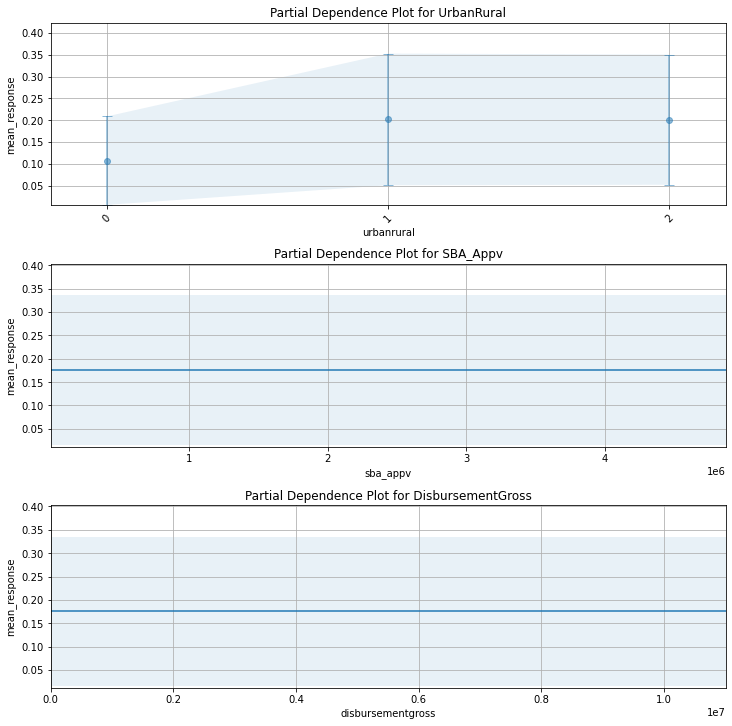

```python
pros_gbm.partial_plot(train, cols=["UrbanRural","SBA_Appv","DisbursementGross"], nbins=52, figsize=(10,10))
```

## Question 4

Calculate and display summary plot of Shapley values. Use `test` dataset to calculate Shapley values.

- What is the most important feature based on Shapley values?
- Why "Zip" feature is not rated at the top when many of the obesrvations have significant high/low Shapley values?

```
<h2o.plot._plot_result._MObject at 0x7f97a0d5bca0>
```

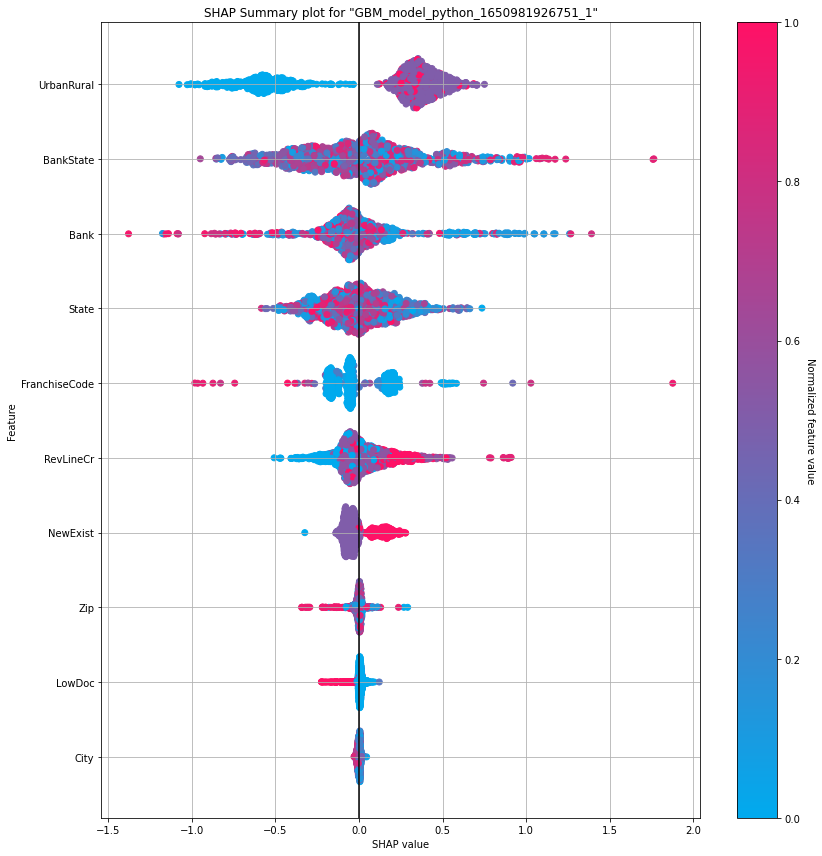

```python
pros_gbm.shap_summary_plot(train)
```

- The most important feature based on Shapley values is "UrbanRural"
- "Zip" feature is not rated at the top when many of the obesrvations have significant high/low Shapley values because it has various unique values that cannot decide the response variable.

## Question 5

Plot individual Shapley values plots for records 0,1 and 4 in test dataset, for the total of 3 plots. Explain each plot in terms of what are most influential features and how they impact model prediction.

```
<h2o.plot._plot_result._MObject at 0x7f97a1275a90>
```

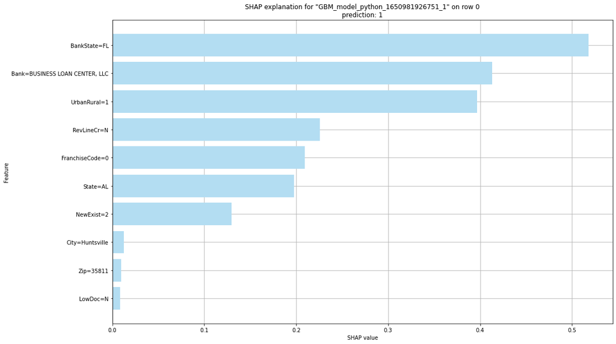

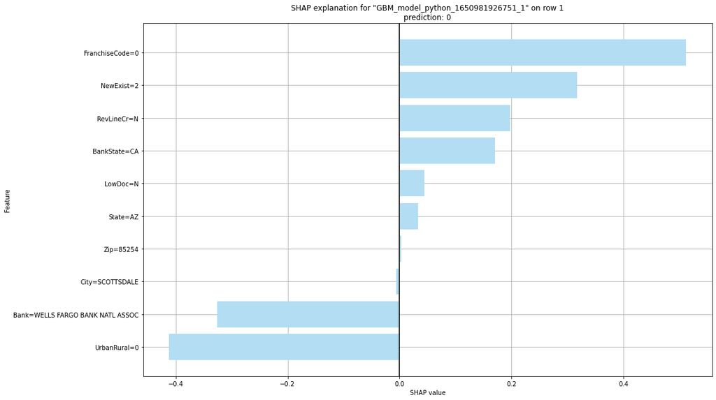

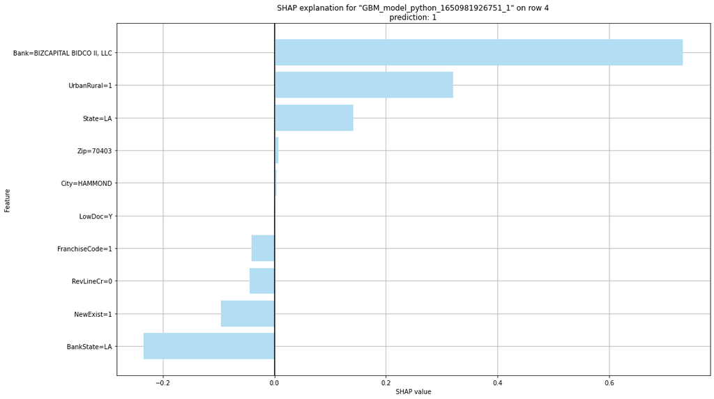

```python
pros_gbm.shap_explain_row_plot(train,row_index = 0)
pros_gbm.shap_explain_row_plot(train,row_index = 1)
pros_gbm.shap_explain_row_plot(train,row_index = 4)
```

- Bankstate=FL, Bank=Business Loan center,LLC, UrbanRural=1 are the most influential factors for record 0 and will have a positive impact on model prediction.
- FranchiseCode=0 will positively influence model prediction, Bank= Wells Fargo Bank NATL ASSOC, and UrbanRural=0 will negatively impact model prediction for record 1.
- Bank= BIZCAPITAL BIDCO ll,LLC will positively affect model prediction, while Bankstate=LA will negatively impact model prediction for record 4.

## Question 6 - optional (no points)

Train decision tree surrogate model with 4 levels and plot the result.